# HW 6

Mikayla Norton

2023-03-23

# 1 Problem 1

ISLR 8.11 (using xgboost): This question uses the Caravan data set.

## 1.1 Part A

Create a training set consisting of the first 1,000 observations, and a test set consisting of the remaining observations.

```r
caravan <- ISLR2::Caravan
caravan <- na.omit(caravan)
#train/test split
n <- 1000 # train size
row_samp <- sample(1:length(caravan$Purchase), n, replace = FALSE)
train <- caravan[row_samp,]
test <- caravan[-row_samp,]
```

## 1.2 Part B

Fit a boosting model to the training set with Purchase as the response and the other variables as predictors. Use 1,000 trees, and a shrinkage value of 0.01. Which predictors appear to be the most important?

```r
quiet(caravan_xgb <- xgboost(data = data.matrix(train[,-86]), nrounds = 1000, max_depth = 2, eta = 0.01, label = as.integer(train$Purchase)-1, objective = "binary:logistic"), all=TRUE)

xgb.importance(colnames(train[,-86]), model = caravan_xgb)
```

| Feature | Gain | Cover | Frequency |
| --- | --- | --- | --- |
| PPERSAUT | 1.122559e-01 | 1.260645e-01 | 0.0784792466 |
| MINKM30 | 8.088452e-02 | 7.697691e-02 | 0.0585978375 |
| PBRAND | 7.742946e-02 | 6.969706e-02 | 0.0725497035 |
| PPLEZIER | 7.701042e-02 | 1.118020e-01 | 0.0544122776 |
| MINKGEM | 7.302774e-02 | 8.759561e-02 | 0.0537146843 |
| MKOOPKLA | 5.584029e-02 | 8.043116e-02 | 0.0551098709 |
| MBERMIDD | 4.557994e-02 | 3.585090e-02 | 0.0533658877 |
| MFGEKIND | 3.855309e-02 | 3.927373e-02 | 0.0481339379 |
| MOPLLAAG | 3.545922e-02 | 1.882834e-02 | 0.0331356819 |
| PWAPART | 3.495925e-02 | 1.051630e-02 | 0.0240669690 |

[output cut: 30 more lines]

## 1.3 Part C

Use the boosting model to predict the response on the test data. Predict that a person will make a purchase if the estimated probability of purchase is greater than 20 %. Form a confusion matrix. What fraction of the people predicted to make a purchase do in fact make one? How does this compare with the results obtained from applying KNN or logistic regression to this data set?

```r
pred <- predict(caravan_xgb, data.matrix(test[,-86]))

pred<- as.factor(ifelse(pred > .2, "Yes", "No"))

confusionMatrix(pred, test$Purchase)$table
```

```
##           Reference
## Prediction   No  Yes
##        No  4361  244
##        Yes  175   42
```

```r
cat("Fraction of the people predicted to make a purchase that do make a purchase: ", confusionMatrix(pred, test$Purchase)$table[4]/(confusionMatrix(pred, test$Purchase)$table[2]+ confusionMatrix(pred, test$Purchase)$table[4]), "\n\n")
```

```
## Fraction of the people predicted to make a purchase that do make a purchase:  0.1935484
```

```r
### KNN
caravan_knn <- scale(select_if(caravan[,-86], is.numeric))

train_knn <- caravan_knn[row_samp,]
test_knn <- caravan_knn[-row_samp,]
train.Y <- caravan[row_samp,]$Purchase
test.Y <- caravan[-row_samp,]$Purchase

knn_mod <- knn(train_knn, test_knn, cl = train.Y , k = 3)
confusionMatrix(knn_mod , reference = as.factor(test.Y))$table
```

```
##           Reference
## Prediction   No  Yes
##        No  4473  275
##        Yes   63   11
```

```r
cat("\nFraction of the people predicted to make a purchase that do make a purchase: ", (confusionMatrix(knn_mod , reference = as.factor(test.Y))$table[4])/(confusionMatrix(knn_mod , reference = as.factor(test.Y))$table[2]+ confusionMatrix(knn_mod , reference = as.factor(test.Y))$table[4]))
```

```
##
## Fraction of the people predicted to make a purchase that do make a purchase:  0.1486486
```

## 1.4 Part D

Perform a grid search for the optimal hyperparameters in the model. Let nrounds go from 50 to 550 in steps of 100, maxdepth from 1 to 2, and eta be 0.01, .1, and .2.

```r
print("nrounds = 50")
```

```
## [1] "nrounds = 50"
```

```r
quiet(caravan_xgb <- xgboost(data = data.matrix(train[,-86]), nrounds = 50, max_depth = 2, eta = 0.01, label = as.integer(train$Purchase)-1, objective = "binary:logistic"), all=TRUE)
cat("\nMax Depth: ", as.integer(caravan_xgb$params[1]), ", eta: ", as.integer(caravan_xgb$params[2]), "\n")
```

```
##
## Max Depth:  2 , eta:  0
```

```r
xgb.importance(colnames(train[,-86]), model = caravan_xgb)[1:5]
```

| Feature | Gain | Cover | Frequency |
| --- | --- | --- | --- |
| PPLEZIER | 0.46031237 | 0.44362268 | 0.29333333 |
| MKOOPKLA | 0.17959364 | 0.24334360 | 0.24000000 |
| MOPLHOOG | 0.07360466 | 0.02318842 | 0.04000000 |
| PPERSAUT | 0.07099360 | 0.09515576 | 0.06666667 |
| MINKM30 | 0.05916505 | 0.09806208 | 0.06666667 |

```r
quiet(caravan_xgb <- xgboost(data = data.matrix(train[,-86]), nrounds = 50, max_depth = 1, eta = 0.01, label = as.integer(train$Purchase)-1, objective = "binary:logistic"), all=TRUE)
cat("\nMax Depth: ", as.integer(caravan_xgb$params[1]), ", eta: ", as.integer(caravan_xgb$params[2]), "\n")
```

```
##
## Max Depth:  1 , eta:  0
```

```r
xgb.importance(colnames(train[,-86]), model = caravan_xgb)[1:5]
```

| Feature | Gain | Cover | Frequency |
| --- | --- | --- | --- |
| PPLEZIER | 0.82024947 | 0.79153344 | 0.78 |
| PPERSAUT | 0.11430357 | 0.13292459 | 0.14 |
| MKOOPKLA | 0.06544696 | 0.07554198 | 0.08 |
| NA | NA | NA | NA |
| NA | NA | NA | NA |

```r
quiet(caravan_xgb <- xgboost(data = data.matrix(train[,-86]), nrounds = 50, max_depth = 2, eta = 0.1, label = as.integer(train$Purchase)-1, objective = "binary:logistic"), all=TRUE)
cat("\nMax Depth: ", as.integer(caravan_xgb$params[1]), ", eta: ", as.integer(caravan_xgb$params[2]), "\n")
```

```
##
## Max Depth:  2 , eta:  0
```

```r
xgb.importance(colnames(train[,-86]), model = caravan_xgb)[1:5]
```

| Feature | Gain | Cover | Frequency |
| --- | --- | --- | --- |
| PPERSAUT | 0.16030681 | 0.16498717 | 0.12751678 |
| MINKM30 | 0.11288824 | 0.09834571 | 0.09395973 |
| MINKGEM | 0.09539768 | 0.11331643 | 0.08053691 |
| PPLEZIER | 0.08583996 | 0.13110474 | 0.06040268 |
| PBRAND | 0.08346976 | 0.06239890 | 0.07382550 |

```r
quiet(caravan_xgb <- xgboost(data = data.matrix(train[,-86]), nrounds = 50, max_depth = 1, eta = 0.1, label = as.integer(train$Purchase)-1, objective = "binary:logistic"), all=TRUE)
cat("\nMax Depth: ", as.integer(caravan_xgb$params[1]), ", eta: ", as.integer(caravan_xgb$params[2]), "\n")
```

```
##
## Max Depth:  1 , eta:  0
```

```r
xgb.importance(colnames(train[,-86]), model = caravan_xgb)[1:5]
```

| Feature | Gain | Cover | Frequency |
| --- | --- | --- | --- |
| PPERSAUT | 0.2614159 | 0.27022473 | 0.26 |
| MINKGEM | 0.1815618 | 0.17949494 | 0.18 |
| MINKM30 | 0.1255653 | 0.09486136 | 0.12 |
| PPLEZIER | 0.1089852 | 0.19095647 | 0.12 |
| PBRAND | 0.1082808 | 0.06582619 | 0.10 |

```r
quiet(caravan_xgb <- xgboost(data = data.matrix(train[,-86]), nrounds = 50, max_depth = 2, eta = 0.2, label = as.integer(train$Purchase)-1, objective = "binary:logistic"), all=TRUE)
cat("\nMax Depth: ", as.integer(caravan_xgb$params[1]), ", eta: ", as.integer(caravan_xgb$params[2]), "\n")
```

```
##
## Max Depth:  2 , eta:  0
```

```r
xgb.importance(colnames(train[,-86]), model = caravan_xgb)[1:5]
```

| Feature | Gain | Cover | Frequency |
| --- | --- | --- | --- |
| PPERSAUT | 0.10539043 | 0.12145400 | 0.07692308 |
| MINKM30 | 0.07442288 | 0.07374303 | 0.05594406 |
| PPLEZIER | 0.07244383 | 0.11453028 | 0.04895105 |
| PBRAND | 0.07215091 | 0.06519222 | 0.06993007 |
| MINKGEM | 0.06992711 | 0.07903031 | 0.04895105 |

```r
quiet(caravan_xgb <- xgboost(data = data.matrix(train[,-86]), nrounds = 50, max_depth = 1, eta = 0.2, label = as.integer(train$Purchase)-1, objective = "binary:logistic"), all=TRUE)
cat("\nMax Depth: ", as.integer(caravan_xgb$params[1]), ", eta: ", as.integer(caravan_xgb$params[2]), "\n")
```

```
##
## Max Depth:  1 , eta:  0
```

```r
xgb.importance(colnames(train[,-86]), model = caravan_xgb)[1:5]
```

| Feature | Gain | Cover | Frequency |
| --- | --- | --- | --- |
| PPERSAUT | 0.20087536 | 0.20255174 | 0.16 |
| MINKGEM | 0.15478888 | 0.15524599 | 0.14 |
| PBRAND | 0.12829233 | 0.10260098 | 0.14 |
| PPLEZIER | 0.10310331 | 0.15546032 | 0.10 |
| MINKM30 | 0.08878292 | 0.05811812 | 0.06 |

```r
print("nrounds = 150")
```

```
## [1] "nrounds = 150"
```

```r
quiet(caravan_xgb <- xgboost(data = data.matrix(train[,-86]), nrounds = 150, max_depth = 2, eta = 0.01, label = as.integer(train$Purchase)-1, objective = "binary:logistic"), all=TRUE)
cat("\nMax Depth: ", as.integer(caravan_xgb$params[1]), ", eta: ", as.integer(caravan_xgb$params[2]), "\n")
```

```
##
## Max Depth:  2 , eta:  0
```

```r
xgb.importance(colnames(train[,-86]), model = caravan_xgb)[1:5]
```

| Feature | Gain | Cover | Frequency |
| --- | --- | --- | --- |
| PPLEZIER | 0.22280340 | 0.24105535 | 0.15333333 |
| PPERSAUT | 0.21855444 | 0.19455744 | 0.17333333 |
| MINKGEM | 0.11821088 | 0.12508210 | 0.09555556 |
| MOPLHOOG | 0.08310020 | 0.03392077 | 0.05111111 |
| MINKM30 | 0.07421318 | 0.07312965 | 0.06222222 |

```r
quiet(caravan_xgb <- xgboost(data = data.matrix(train[,-86]), nrounds = 150, max_depth = 1, eta = 0.01, label = as.integer(train$Purchase)-1, objective = "binary:logistic"), all=TRUE)
cat("\nMax Depth: ", as.integer(caravan_xgb$params[1]), ", eta: ", as.integer(caravan_xgb$params[2]), "\n")
```

```
##
## Max Depth:  1 , eta:  0
```

```r
xgb.importance(colnames(train[,-86]), model = caravan_xgb)[1:5]
```

| Feature | Gain | Cover | Frequency |
| --- | --- | --- | --- |
| PPERSAUT | 0.29844437 | 0.28660265 | 0.3066667 |
| PPLEZIER | 0.27553533 | 0.32833209 | 0.2666667 |
| MINKGEM | 0.20555415 | 0.18681205 | 0.2066667 |
| MKOOPKLA | 0.10333694 | 0.11410963 | 0.1133333 |
| MOSTYPE | 0.06421219 | 0.04902803 | 0.0600000 |

```r
quiet(caravan_xgb <- xgboost(data = data.matrix(train[,-86]), nrounds = 150, max_depth = 2, eta = 0.1, label = as.integer(train$Purchase)-1, objective = "binary:logistic"), all=TRUE)
cat("\nMax Depth: ", as.integer(caravan_xgb$params[1]), ", eta: ", as.integer(caravan_xgb$params[2]), "\n")
```

```
##
## Max Depth:  2 , eta:  0
```

```r
xgb.importance(colnames(train[,-86]), model = caravan_xgb)[1:5]
```

| Feature | Gain | Cover | Frequency |
| --- | --- | --- | --- |
| PPERSAUT | 0.09231820 | 0.09842686 | 0.05660377 |
| MINKM30 | 0.08010903 | 0.07511375 | 0.06367925 |
| PBRAND | 0.07365725 | 0.06850742 | 0.06839623 |
| MINKGEM | 0.06554802 | 0.07443267 | 0.04716981 |
| PPLEZIER | 0.06365411 | 0.09082709 | 0.04481132 |

```r
quiet(caravan_xgb <- xgboost(data = data.matrix(train[,-86]), nrounds = 150, max_depth = 1, eta = 0.1, label = as.integer(train$Purchase)-1, objective = "binary:logistic"), all=TRUE)
cat("\nMax Depth: ", as.integer(caravan_xgb$params[1]), ", eta: ", as.integer(caravan_xgb$params[2]), "\n")
```

```
##
## Max Depth:  1 , eta:  0
```

```r
xgb.importance(colnames(train[,-86]), model = caravan_xgb)[1:5]
```

| Feature | Gain | Cover | Frequency |
| --- | --- | --- | --- |
| PPERSAUT | 0.17992439 | 0.16263519 | 0.12000000 |
| MINKGEM | 0.14164023 | 0.13081193 | 0.11333333 |
| PBRAND | 0.11829893 | 0.09275500 | 0.11333333 |
| MINKM30 | 0.10449009 | 0.09669984 | 0.10666667 |
| PPLEZIER | 0.09641641 | 0.13190351 | 0.08666667 |

```r
quiet(caravan_xgb <- xgboost(data = data.matrix(train[,-86]), nrounds = 150, max_depth = 2, eta = 0.2, label = as.integer(train$Purchase)-1, objective = "binary:logistic"), all=TRUE)
cat("\nMax Depth: ", as.integer(caravan_xgb$params[1]), ", eta: ", as.integer(caravan_xgb$params[2]), "\n")
```

```
##
## Max Depth:  2 , eta:  0
```

```r
xgb.importance(colnames(train[,-86]), model = caravan_xgb)[1:5]
```

| Feature | Gain | Cover | Frequency |
| --- | --- | --- | --- |
| PBRAND | 0.08523905 | 0.06746631 | 0.08274232 |
| PPERSAUT | 0.06691800 | 0.06367342 | 0.03309693 |
| MINKGEM | 0.05937851 | 0.05720787 | 0.04255319 |
| MINKM30 | 0.05252016 | 0.05574636 | 0.04018913 |
| MFGEKIND | 0.05062200 | 0.08001454 | 0.08037825 |

```r
quiet(caravan_xgb <- xgboost(data = data.matrix(train[,-86]), nrounds = 150, max_depth = 1, eta = 0.2, label = as.integer(train$Purchase)-1, objective = "binary:logistic"), all=TRUE)
cat("\nMax Depth: ", as.integer(caravan_xgb$params[1]), ", eta: ", as.integer(caravan_xgb$params[2]), "\n")
```

```
##
## Max Depth:  1 , eta:  0
```

```r
xgb.importance(colnames(train[,-86]), model = caravan_xgb)[1:5]
```

| Feature | Gain | Cover | Frequency |
| --- | --- | --- | --- |
| PPERSAUT | 0.14079790 | 0.09591057 | 0.06000000 |
| MINKGEM | 0.11896494 | 0.09146363 | 0.07333333 |
| MINKM30 | 0.10842633 | 0.09844439 | 0.10666667 |
| PBRAND | 0.10352046 | 0.07348392 | 0.08000000 |
| PPLEZIER | 0.08335261 | 0.09153132 | 0.06000000 |

```r
print("nrounds = 250")
```

```
## [1] "nrounds = 250"
```

```r
quiet(caravan_xgb <- xgboost(data = data.matrix(train[,-86]), nrounds = 250, max_depth = 2, eta = 0.01, label = as.integer(train$Purchase)-1, objective = "binary:logistic"), all=TRUE)
cat("\nMax Depth: ", as.integer(caravan_xgb$params[1]), ", eta: ", as.integer(caravan_xgb$params[2]), "\n")
```

```
##
## Max Depth:  2 , eta:  0
```

```r
xgb.importance(colnames(train[,-86]), model = caravan_xgb)[1:5]
```

| Feature | Gain | Cover | Frequency |
| --- | --- | --- | --- |
| PPERSAUT | 0.20361122 | 0.18712376 | 0.1613333 |
| PPLEZIER | 0.14350101 | 0.18500050 | 0.1040000 |
| MINKGEM | 0.12050479 | 0.13095018 | 0.0960000 |
| MINKM30 | 0.08451215 | 0.08383546 | 0.0680000 |
| PBRAND | 0.07305847 | 0.03742463 | 0.0640000 |

```r
quiet(caravan_xgb <- xgboost(data = data.matrix(train[,-86]), nrounds = 250, max_depth = 1, eta = 0.01, label = as.integer(train$Purchase)-1, objective = "binary:logistic"), all=TRUE)
cat("\nMax Depth: ", as.integer(caravan_xgb$params[1]), ", eta: ", as.integer(caravan_xgb$params[2]), "\n")
```

```
##
## Max Depth:  1 , eta:  0
```

```r
xgb.importance(colnames(train[,-86]), model = caravan_xgb)[1:5]
```

| Feature | Gain | Cover | Frequency |
| --- | --- | --- | --- |
| PPERSAUT | 0.30798935 | 0.29656374 | 0.312 |
| MINKGEM | 0.21160757 | 0.19714329 | 0.212 |
| PPLEZIER | 0.14707641 | 0.23998830 | 0.160 |
| MINKM30 | 0.11672761 | 0.07698888 | 0.104 |
| MOSTYPE | 0.09486008 | 0.07081584 | 0.088 |

```r
quiet(caravan_xgb <- xgboost(data = data.matrix(train[,-86]), nrounds = 250, max_depth = 2, eta = 0.1, label = as.integer(train$Purchase)-1, objective = "binary:logistic"), all=TRUE)
cat("\nMax Depth: ", as.integer(caravan_xgb$params[1]), ", eta: ", as.integer(caravan_xgb$params[2]), "\n")
```

```
##
## Max Depth:  2 , eta:  0
```

```r
xgb.importance(colnames(train[,-86]), model = caravan_xgb)[1:5]
```

| Feature | Gain | Cover | Frequency |
| --- | --- | --- | --- |
| PBRAND | 0.08298644 | 0.07318066 | 0.07868383 |
| PPERSAUT | 0.07416299 | 0.07199832 | 0.03719599 |
| MINKM30 | 0.06671586 | 0.05975446 | 0.04577969 |
| MINKGEM | 0.06010192 | 0.06205900 | 0.04291845 |
| MFGEKIND | 0.05473265 | 0.06762130 | 0.07153076 |

```r
quiet(caravan_xgb <- xgboost(data = data.matrix(train[,-86]), nrounds = 250, max_depth = 1, eta = 0.1, label = as.integer(train$Purchase)-1, objective = "binary:logistic"), all=TRUE)
cat("\nMax Depth: ", as.integer(caravan_xgb$params[1]), ", eta: ", as.integer(caravan_xgb$params[2]), "\n")
```

```
##
## Max Depth:  1 , eta:  0
```

```r
xgb.importance(colnames(train[,-86]), model = caravan_xgb)[1:5]
```

| Feature | Gain | Cover | Frequency |
| --- | --- | --- | --- |
| PPERSAUT | 0.15296422 | 0.11368636 | 0.076 |
| MINKGEM | 0.12382227 | 0.09847349 | 0.080 |
| MINKM30 | 0.11221300 | 0.11385288 | 0.124 |
| PBRAND | 0.10767130 | 0.07905856 | 0.088 |
| PPLEZIER | 0.08618894 | 0.09924863 | 0.064 |

```r
quiet(caravan_xgb <- xgboost(data = data.matrix(train[,-86]), nrounds = 250, max_depth = 2, eta = 0.2, label = as.integer(train$Purchase)-1, objective = "binary:logistic"), all=TRUE)
cat("\nMax Depth: ", as.integer(caravan_xgb$params[1]), ", eta: ", as.integer(caravan_xgb$params[2]), "\n")
```

```
##
## Max Depth:  2 , eta:  0
```

```r
xgb.importance(colnames(train[,-86]), model = caravan_xgb)[1:5]
```

| Feature | Gain | Cover | Frequency |
| --- | --- | --- | --- |
| PBRAND | 0.08492844 | 0.06015733 | 0.07194245 |
| PPERSAUT | 0.06266853 | 0.04974286 | 0.03165468 |
| MINKGEM | 0.05460715 | 0.04745007 | 0.03741007 |
| MINKM30 | 0.04737054 | 0.04790100 | 0.03453237 |
| MOSTYPE | 0.04538337 | 0.06073335 | 0.05467626 |

```r
quiet(caravan_xgb <- xgboost(data = data.matrix(train[,-86]), nrounds = 250, max_depth = 1, eta = 0.2, label = as.integer(train$Purchase)-1, objective = "binary:logistic"), all=TRUE)
cat("\nMax Depth: ", as.integer(caravan_xgb$params[1]), ", eta: ", as.integer(caravan_xgb$params[2]), "\n")
```

```
##
## Max Depth:  1 , eta:  0
```

```r
xgb.importance(colnames(train[,-86]), model = caravan_xgb)[1:5]
```

| Feature | Gain | Cover | Frequency |
| --- | --- | --- | --- |
| PPERSAUT | 0.12261342 | 0.06607435 | 0.040 |
| MINKGEM | 0.10515689 | 0.06662561 | 0.052 |
| MINKM30 | 0.10174789 | 0.08507500 | 0.088 |
| PBRAND | 0.09300601 | 0.05834086 | 0.060 |
| PPLEZIER | 0.07437462 | 0.06666431 | 0.044 |

```r
print("nrounds = 350")
```

```
## [1] "nrounds = 350"
```

```r
quiet(caravan_xgb <- xgboost(data = data.matrix(train[,-86]), nrounds = 350, max_depth = 2, eta = 0.01, label = as.integer(train$Purchase)-1, objective = "binary:logistic"), all=TRUE)
cat("\nMax Depth: ", as.integer(caravan_xgb$params[1]), ", eta: ", as.integer(caravan_xgb$params[2]), "\n")
```

```
##
## Max Depth:  2 , eta:  0
```

```r
xgb.importance(colnames(train[,-86]), model = caravan_xgb)[1:5]
```

| Feature | Gain | Cover | Frequency |
| --- | --- | --- | --- |
| PPERSAUT | 0.18943322 | 0.18176112 | 0.15142857 |
| MINKM30 | 0.10763080 | 0.09861245 | 0.09047619 |
| PPLEZIER | 0.10708312 | 0.15676346 | 0.07714286 |
| MINKGEM | 0.10663225 | 0.12246186 | 0.08666667 |
| PBRAND | 0.08379128 | 0.05214076 | 0.07238095 |

```r
quiet(caravan_xgb <- xgboost(data = data.matrix(train[,-86]), nrounds = 350, max_depth = 1, eta = 0.01, label = as.integer(train$Purchase)-1, objective = "binary:logistic"), all=TRUE)
cat("\nMax Depth: ", as.integer(caravan_xgb$params[1]), ", eta: ", as.integer(caravan_xgb$params[2]), "\n")
```

```
##
## Max Depth:  1 , eta:  0
```

```r
xgb.importance(colnames(train[,-86]), model = caravan_xgb)[1:5]
```

| Feature | Gain | Cover | Frequency |
| --- | --- | --- | --- |
| PPERSAUT | 0.28999442 | 0.28913577 | 0.29428571 |
| MINKGEM | 0.19292515 | 0.18998164 | 0.19428571 |
| MINKM30 | 0.13031199 | 0.09042814 | 0.12000000 |
| PPLEZIER | 0.10117636 | 0.20134837 | 0.11428571 |
| PBRAND | 0.09873983 | 0.05442510 | 0.08857143 |

```r
quiet(caravan_xgb <- xgboost(data = data.matrix(train[,-86]), nrounds = 350, max_depth = 2, eta = 0.1, label = as.integer(train$Purchase)-1, objective = "binary:logistic"), all=TRUE)
cat("\nMax Depth: ", as.integer(caravan_xgb$params[1]), ", eta: ", as.integer(caravan_xgb$params[2]), "\n")
```

```
##
## Max Depth:  2 , eta:  0
```

```r
xgb.importance(colnames(train[,-86]), model = caravan_xgb)[1:5]
```

| Feature | Gain | Cover | Frequency |
| --- | --- | --- | --- |
| PBRAND | 0.08493149 | 0.06901472 | 0.07628866 |
| PPERSAUT | 0.06498582 | 0.05655987 | 0.02680412 |
| MINKM30 | 0.05976462 | 0.05083186 | 0.03711340 |
| MINKGEM | 0.05677608 | 0.05490666 | 0.04020619 |
| MFGEKIND | 0.05187545 | 0.06341611 | 0.06288660 |

```r
quiet(caravan_xgb <- xgboost(data = data.matrix(train[,-86]), nrounds = 350, max_depth = 1, eta = 0.1, label = as.integer(train$Purchase)-1, objective = "binary:logistic"), all=TRUE)
cat("\nMax Depth: ", as.integer(caravan_xgb$params[1]), ", eta: ", as.integer(caravan_xgb$params[2]), "\n")
```

```
##
## Max Depth:  1 , eta:  0
```

```r
xgb.importance(colnames(train[,-86]), model = caravan_xgb)[1:5]
```

| Feature | Gain | Cover | Frequency |
| --- | --- | --- | --- |
| PPERSAUT | 0.13875466 | 0.08888599 | 0.05714286 |
| MINKGEM | 0.11453457 | 0.08210538 | 0.06571429 |
| MINKM30 | 0.10810387 | 0.10338773 | 0.10857143 |
| PBRAND | 0.10094749 | 0.06971390 | 0.07428571 |
| PPLEZIER | 0.08072467 | 0.08271425 | 0.05428571 |

```r
quiet(caravan_xgb <- xgboost(data = data.matrix(train[,-86]), nrounds = 350, max_depth = 2, eta = 0.2, label = as.integer(train$Purchase)-1, objective = "binary:logistic"), all=TRUE)
cat("\nMax Depth: ", as.integer(caravan_xgb$params[1]), ", eta: ", as.integer(caravan_xgb$params[2]), "\n")
```

```
##
## Max Depth:  2 , eta:  0
```

```r
xgb.importance(colnames(train[,-86]), model = caravan_xgb)[1:5]
```

| Feature | Gain | Cover | Frequency |
| --- | --- | --- | --- |
| PBRAND | 0.08657140 | 0.05403554 | 0.06398349 |
| PPERSAUT | 0.05973062 | 0.04383276 | 0.02992776 |
| MINKGEM | 0.05150938 | 0.04213944 | 0.03302374 |
| MOSTYPE | 0.04835675 | 0.06469893 | 0.06088751 |
| MINKM30 | 0.04473652 | 0.04454892 | 0.03302374 |

```r
quiet(caravan_xgb <- xgboost(data = data.matrix(train[,-86]), nrounds = 350, max_depth = 1, eta = 0.2, label = as.integer(train$Purchase)-1, objective = "binary:logistic"), all=TRUE)
cat("\nMax Depth: ", as.integer(caravan_xgb$params[1]), ", eta: ", as.integer(caravan_xgb$params[2]), "\n")
```

```
##
## Max Depth:  1 , eta:  0
```

```r
xgb.importance(colnames(train[,-86]), model = caravan_xgb)[1:5]
```

| Feature | Gain | Cover | Frequency |
| --- | --- | --- | --- |
| PPERSAUT | 0.11288991 | 0.05189505 | 0.03142857 |
| MINKGEM | 0.09942879 | 0.05989438 | 0.04857143 |
| MINKM30 | 0.09753255 | 0.07624911 | 0.07714286 |
| PBRAND | 0.08855395 | 0.05374867 | 0.05428571 |
| PPLEZIER | 0.07064101 | 0.05742611 | 0.04000000 |

```r
print("nrounds = 450")
```

```
## [1] "nrounds = 450"
```

```r
quiet(caravan_xgb <- xgboost(data = data.matrix(train[,-86]), nrounds = 450, max_depth = 2, eta = 0.01, label = as.integer(train$Purchase)-1, objective = "binary:logistic"), all=TRUE)
cat("\nMax Depth: ", as.integer(caravan_xgb$params[1]), ", eta: ", as.integer(caravan_xgb$params[2]), "\n")
```

```
##
## Max Depth:  2 , eta:  0
```

```r
xgb.importance(colnames(train[,-86]), model = caravan_xgb)[1:5]
```

| Feature | Gain | Cover | Frequency |
| --- | --- | --- | --- |
| PPERSAUT | 0.16829128 | 0.17228221 | 0.13338301 |
| MINKM30 | 0.10750382 | 0.09984755 | 0.08941878 |
| MINKGEM | 0.09460995 | 0.11429096 | 0.07675112 |
| PPLEZIER | 0.09327856 | 0.14332082 | 0.06706408 |
| PBRAND | 0.09043670 | 0.06098152 | 0.08047690 |

```r
quiet(caravan_xgb <- xgboost(data = data.matrix(train[,-86]), nrounds = 450, max_depth = 1, eta = 0.01, label = as.integer(train$Purchase)-1, objective = "binary:logistic"), all=TRUE)
cat("\nMax Depth: ", as.integer(caravan_xgb$params[1]), ", eta: ", as.integer(caravan_xgb$params[2]), "\n")
```

```
##
## Max Depth:  1 , eta:  0
```

```r
xgb.importance(colnames(train[,-86]), model = caravan_xgb)[1:5]
```

| Feature | Gain | Cover | Frequency |
| --- | --- | --- | --- |
| PPERSAUT | 0.2699944 | 0.27740205 | 0.2711111 |
| MINKGEM | 0.1800134 | 0.18279583 | 0.1800000 |
| MINKM30 | 0.1243646 | 0.09160207 | 0.1155556 |
| PBRAND | 0.1092066 | 0.06579903 | 0.1022222 |
| PPLEZIER | 0.1024735 | 0.19037447 | 0.1133333 |

```r
quiet(caravan_xgb <- xgboost(data = data.matrix(train[,-86]), nrounds = 450, max_depth = 2, eta = 0.1, label = as.integer(train$Purchase)-1, objective = "binary:logistic"), all=TRUE)
cat("\nMax Depth: ", as.integer(caravan_xgb$params[1]), ", eta: ", as.integer(caravan_xgb$params[2]), "\n")
```

```
##
## Max Depth:  2 , eta:  0
```

```r
xgb.importance(colnames(train[,-86]), model = caravan_xgb)[1:5]
```

| Feature | Gain | Cover | Frequency |
| --- | --- | --- | --- |
| PBRAND | 0.08370785 | 0.06591650 | 0.07252216 |
| PPERSAUT | 0.06112866 | 0.04763198 | 0.02336825 |
| MINKM30 | 0.05631495 | 0.04388390 | 0.03142627 |
| MINKGEM | 0.05522144 | 0.05380210 | 0.04190169 |
| MFGEKIND | 0.04943806 | 0.06328384 | 0.05962933 |

```r
quiet(caravan_xgb <- xgboost(data = data.matrix(train[,-86]), nrounds = 450, max_depth = 1, eta = 0.1, label = as.integer(train$Purchase)-1, objective = "binary:logistic"), all=TRUE)
cat("\nMax Depth: ", as.integer(caravan_xgb$params[1]), ", eta: ", as.integer(caravan_xgb$params[2]), "\n")
```

```
##
## Max Depth:  1 , eta:  0
```

```r
xgb.importance(colnames(train[,-86]), model = caravan_xgb)[1:5]
```

| Feature | Gain | Cover | Frequency |
| --- | --- | --- | --- |
| PPERSAUT | 0.12879239 | 0.07196247 | 0.04444444 |
| MINKGEM | 0.10777827 | 0.07028954 | 0.05555556 |
| MINKM30 | 0.10398478 | 0.09322574 | 0.09555556 |
| PBRAND | 0.09647956 | 0.06404970 | 0.06666667 |
| PPLEZIER | 0.07703797 | 0.07267778 | 0.04888889 |

```r
quiet(caravan_xgb <- xgboost(data = data.matrix(train[,-86]), nrounds = 450, max_depth = 2, eta = 0.2, label = as.integer(train$Purchase)-1, objective = "binary:logistic"), all=TRUE)
cat("\nMax Depth: ", as.integer(caravan_xgb$params[1]), ", eta: ", as.integer(caravan_xgb$params[2]), "\n")
```

```
##
## Max Depth:  2 , eta:  0
```

```r
xgb.importance(colnames(train[,-86]), model = caravan_xgb)[1:5]
```

| Feature | Gain | Cover | Frequency |
| --- | --- | --- | --- |
| PBRAND | 0.08516889 | 0.04835067 | 0.05631537 |
| PPERSAUT | 0.06323398 | 0.04266019 | 0.03700724 |
| MINKGEM | 0.04967026 | 0.03786214 | 0.02976669 |
| MOSTYPE | 0.04852227 | 0.07003550 | 0.06596943 |
| MINKM30 | 0.04303840 | 0.04371814 | 0.03218021 |

```r
quiet(caravan_xgb <- xgboost(data = data.matrix(train[,-86]), nrounds = 450, max_depth = 1, eta = 0.2, label = as.integer(train$Purchase)-1, objective = "binary:logistic"), all=TRUE)
cat("\nMax Depth: ", as.integer(caravan_xgb$params[1]), ", eta: ", as.integer(caravan_xgb$params[2]), "\n")
```

```
##
## Max Depth:  1 , eta:  0
```

```r
xgb.importance(colnames(train[,-86]), model = caravan_xgb)[1:5]
```

| Feature | Gain | Cover | Frequency |
| --- | --- | --- | --- |
| PPERSAUT | 0.10605833 | 0.04161804 | 0.02444444 |
| MINKGEM | 0.09461002 | 0.05199615 | 0.04222222 |
| MINKM30 | 0.09409881 | 0.06906397 | 0.06888889 |
| PBRAND | 0.08434674 | 0.04706203 | 0.04666667 |
| PPLEZIER | 0.06814499 | 0.05199970 | 0.03777778 |

```r
print("nrounds = 550")
```

```
## [1] "nrounds = 550"
```

```r
quiet(caravan_xgb <- xgboost(data = data.matrix(train[,-86]), nrounds = 550, max_depth = 2, eta = 0.01, label = as.integer(train$Purchase)-1, objective = "binary:logistic"), all=TRUE)
cat("\nMax Depth: ", as.integer(caravan_xgb$params[1]), ", eta: ", as.integer(caravan_xgb$params[2]), "\n")
```

```
##
## Max Depth:  2 , eta:  0
```

```r
xgb.importance(colnames(train[,-86]), model = caravan_xgb)[1:5]
```

| Feature | Gain | Cover | Frequency |
| --- | --- | --- | --- |
| PPERSAUT | 0.15086990 | 0.16195192 | 0.11800860 |
| MINKM30 | 0.09895734 | 0.09420369 | 0.07928703 |
| PBRAND | 0.08868050 | 0.06441287 | 0.08051629 |
| PPLEZIER | 0.08685578 | 0.13675460 | 0.06453596 |
| MINKGEM | 0.08677269 | 0.10907694 | 0.07068224 |

```r
quiet(caravan_xgb <- xgboost(data = data.matrix(train[,-86]), nrounds = 550, max_depth = 1, eta = 0.01, label = as.integer(train$Purchase)-1, objective = "binary:logistic"), all=TRUE)
cat("\nMax Depth: ", as.integer(caravan_xgb$params[1]), ", eta: ", as.integer(caravan_xgb$params[2]), "\n")
```

```
##
## Max Depth:  1 , eta:  0
```

```r
xgb.importance(colnames(train[,-86]), model = caravan_xgb)[1:5]
```

| Feature | Gain | Cover | Frequency |
| --- | --- | --- | --- |
| PPERSAUT | 0.2538504 | 0.26490258 | 0.2490909 |
| MINKGEM | 0.1733102 | 0.17762092 | 0.1709091 |
| MINKM30 | 0.1184181 | 0.09047362 | 0.1090909 |
| PBRAND | 0.1108894 | 0.07117238 | 0.1054545 |
| PPLEZIER | 0.1074022 | 0.18541977 | 0.1181818 |

```r
quiet(caravan_xgb <- xgboost(data = data.matrix(train[,-86]), nrounds = 550, max_depth = 2, eta = 0.1, label = as.integer(train$Purchase)-1, objective = "binary:logistic"), all=TRUE)
cat("\nMax Depth: ", as.integer(caravan_xgb$params[1]), ", eta: ", as.integer(caravan_xgb$params[2]), "\n")
```

```
##
## Max Depth:  2 , eta:  0
```

```r
xgb.importance(colnames(train[,-86]), model = caravan_xgb)[1:5]
```

| Feature | Gain | Cover | Frequency |
| --- | --- | --- | --- |
| PBRAND | 0.08326113 | 0.06541108 | 0.07166338 |
| PPERSAUT | 0.06045412 | 0.04284090 | 0.02366864 |
| MINKM30 | 0.05373653 | 0.04082672 | 0.02892834 |
| MINKGEM | 0.05202131 | 0.04987047 | 0.03747535 |
| MFGEKIND | 0.04728297 | 0.06187656 | 0.05588429 |

```r
quiet(caravan_xgb <- xgboost(data = data.matrix(train[,-86]), nrounds = 550, max_depth = 1, eta = 0.1, label = as.integer(train$Purchase)-1, objective = "binary:logistic"), all=TRUE)
cat("\nMax Depth: ", as.integer(caravan_xgb$params[1]), ", eta: ", as.integer(caravan_xgb$params[2]), "\n")
```

```
##
## Max Depth:  1 , eta:  0
```

```r
xgb.importance(colnames(train[,-86]), model = caravan_xgb)[1:5]
```

| Feature | Gain | Cover | Frequency |
| --- | --- | --- | --- |
| PPERSAUT | 0.12228135 | 0.06217748 | 0.03818182 |
| MINKGEM | 0.10352361 | 0.06392922 | 0.05090909 |
| MINKM30 | 0.10151996 | 0.08796154 | 0.08909091 |
| PBRAND | 0.09328976 | 0.06023686 | 0.06181818 |
| PPLEZIER | 0.07438944 | 0.06592984 | 0.04545455 |

```r
quiet(caravan_xgb <- xgboost(data = data.matrix(train[,-86]), nrounds = 550, max_depth = 2, eta = 0.2, label = as.integer(train$Purchase)-1, objective = "binary:logistic"), all=TRUE)
cat("\nMax Depth: ", as.integer(caravan_xgb$params[1]), ", eta: ", as.integer(caravan_xgb$params[2]), "\n")
```

```
##
## Max Depth:  2 , eta:  0
```

```r
xgb.importance(colnames(train[,-86]), model = caravan_xgb)[1:5]
```

| Feature | Gain | Cover | Frequency |
| --- | --- | --- | --- |
| PBRAND | 0.08580580 | 0.04568181 | 0.05544554 |
| PPERSAUT | 0.06306858 | 0.04067208 | 0.03564356 |
| MOSTYPE | 0.04901788 | 0.07349597 | 0.06996700 |
| MINKGEM | 0.04870469 | 0.03597129 | 0.02838284 |
| PWAPART | 0.04276908 | 0.01251158 | 0.03366337 |

```r
quiet(caravan_xgb <- xgboost(data = data.matrix(train[,-86]), nrounds = 550, max_depth = 1, eta = 0.2, label = as.integer(train$Purchase)-1, objective = "binary:logistic"), all=TRUE)
cat("\nMax Depth: ", as.integer(caravan_xgb$params[1]), ", eta: ", as.integer(caravan_xgb$params[2]), "\n")
```

```
##
## Max Depth:  1 , eta:  0
```

```r
xgb.importance(colnames(train[,-86]), model = caravan_xgb)[1:5]
```

| Feature | Gain | Cover | Frequency |
| --- | --- | --- | --- |
| PPERSAUT | 0.10152123 | 0.03647094 | 0.02181818 |
| MINKGEM | 0.09238906 | 0.05164015 | 0.04363636 |
| MINKM30 | 0.09153951 | 0.06433124 | 0.06363636 |
| PBRAND | 0.08130887 | 0.04266706 | 0.04181818 |
| PPLEZIER | 0.06587585 | 0.04680334 | 0.03454545 |

# 2 Problem 2

ISLR2 9.7: In this problem, you will use support vector approaches in order to predict whether a given car gets high or low gas mileage based on the Auto data set.

## 2.1 Part A

Create a binary variable that takes on a 1 for cars with gas mileage above the median, and a 0 for cars with gas mileage below the median.

```r
auto <- ISLR2::Auto
auto$mpg <- as.integer(ifelse(auto$mpg > median(auto$mpg), 1, 0))
```

## 2.2 Part B

(with a 80/20 train/test split) Fit a support vector classifier to the data with various values of cost, in order to predict whether a car gets high or low gas mileage. Report the cross-validation errors associated with different values of this parameter. Comment on your results. Note you will need to fit the classifier without the gas mileage variable to produce sensible results.

```r
split_pct <- 0.8
n <- length(auto$mpg)*split_pct # train size
row_samp <- sample(1:length(auto$mpg), n, replace = FALSE)
train <- auto[row_samp,]
test <- auto[-row_samp,]

svm_mod <- svm(mpg ~ cylinders + displacement + horsepower + weight, data = train, type = 'C-classification', kernel = 'linear', cost = 1, gamma = 0.5)
cat("Cost: ", svm_mod$cost)
```

```
## Cost:  1
```

```r
pred <- predict(svm_mod, test)
confusionMatrix(as.factor(pred), as.factor(test$mpg))$table
```

```
##           Reference
## Prediction  0  1
##          0 34  4
##          1  7 34
```

```r
confusionMatrix(as.factor(pred), as.factor(test$mpg))$overall[1]
```

```
##  Accuracy
## 0.8607595
```

```r
svm_mod <- svm(mpg ~ cylinders + displacement + horsepower + weight, data = train, type = 'C-classification', kernel = 'linear', cost = 0.01, gamma = 0.5)
cat("\nCost: ", svm_mod$cost)
```

```
##
## Cost:  0.01
```

```r
pred <- predict(svm_mod, test)
confusionMatrix(as.factor(pred), as.factor(test$mpg))$table
```

```
##           Reference
## Prediction  0  1
##          0 34  5
##          1  7 33
```

```r
confusionMatrix(as.factor(pred), as.factor(test$mpg))$overall[1]
```

```
##  Accuracy
## 0.8481013
```

```r
svm_mod <- svm(mpg ~ cylinders + displacement + horsepower + weight, data = train, type = 'C-classification', kernel = 'linear', cost = 10, gamma = 0.5)
cat("\nCost: ", svm_mod$cost)
```

```
##
## Cost:  10
```

```r
pred <- predict(svm_mod, test)
confusionMatrix(as.factor(pred), as.factor(test$mpg))$table
```

```
##           Reference
## Prediction  0  1
##          0 34  4
##          1  7 34
```

```r
confusionMatrix(as.factor(pred), as.factor(test$mpg))$overall[1]
```

```
##  Accuracy
## 0.8607595
```

```r
svm_mod <- svm(mpg ~ cylinders + displacement + horsepower + weight, data = train, type = 'C-classification', kernel = 'linear', cost = 100, gamma = 0.5)
cat("\nCost: ", svm_mod$cost)
```

```
##
## Cost:  100
```

```r
pred <- predict(svm_mod, test)
confusionMatrix(as.factor(pred), as.factor(test$mpg))$table
```

```
##           Reference
## Prediction  0  1
##          0 34  5
##          1  7 33
```

```r
confusionMatrix(as.factor(pred), as.factor(test$mpg))$overall[1]
```

```
##  Accuracy
## 0.8481013
```

Cost Parameter did not impact results significantly between the range of 0.01 to 100.

## 2.3 Part C

Now repeat (b), this time using SVMs with radial and polynomial basis kernels, with different values of gamma and degree and cost. Comment on your results.

```r
print("Radial SVMs with variable parameters")
```

```
## [1] "Radial SVMs with variable parameters"
```

```r
svm_mod <- svm(mpg ~ cylinders + displacement + horsepower + weight, data = train, type = 'C-classification', kernel = 'radial', cost = 1, gamma = 0.5)
pred <- predict(svm_mod, test)
cat("\nCost: ", svm_mod$cost, ", Gamma: ", svm_mod$gamma, ", Degree: ", svm_mod$degree, ", Accuracy: ", confusionMatrix(as.factor(pred), as.factor(test$mpg))$overall[1])
```

```
##
## Cost:  1 , Gamma:  0.5 , Degree:  3 , Accuracy:  0.8481013
```

```r
svm_mod <- svm(mpg ~ cylinders + displacement + horsepower + weight, data = train, type = 'C-classification', kernel = 'radial', cost = 0.01, gamma = 0.5)
pred <- predict(svm_mod, test)
cat("\nCost: ", svm_mod$cost, ", Gamma: ", svm_mod$gamma, ", Degree: ", svm_mod$degree, ", Accuracy: ", confusionMatrix(as.factor(pred), as.factor(test$mpg))$overall[1])
```

```
##
## Cost:  0.01 , Gamma:  0.5 , Degree:  3 , Accuracy:  0.8481013
```

```r
svm_mod <- svm(mpg ~ cylinders + displacement + horsepower + weight, data = train, type = 'C-classification', kernel = 'radial', cost = 100, gamma = 0.5)
pred <- predict(svm_mod, test)
cat("\nCost: ", svm_mod$cost, ", Gamma: ", svm_mod$gamma, ", Degree: ", svm_mod$degree, ", Accuracy: ", confusionMatrix(as.factor(pred), as.factor(test$mpg))$overall[1])
```

```
##
## Cost:  100 , Gamma:  0.5 , Degree:  3 , Accuracy:  0.8734177
```

```r
svm_mod <- svm(mpg ~ cylinders + displacement + horsepower + weight, data = train, type = 'C-classification', kernel = 'radial', cost = 1, gamma = 5)
pred <- predict(svm_mod, test)
cat("\nCost: ", svm_mod$cost, ", Gamma: ", svm_mod$gamma, ", Degree: ", svm_mod$degree, ", Accuracy: ", confusionMatrix(as.factor(pred), as.factor(test$mpg))$overall[1])
```

```
##
## Cost:  1 , Gamma:  5 , Degree:  3 , Accuracy:  0.8607595
```

```r
svm_mod <- svm(mpg ~ cylinders + displacement + horsepower + weight, data = train, type = 'C-classification', kernel = 'radial', cost = 1, gamma = 0.05)
pred <- predict(svm_mod, test)
cat("\nCost: ", svm_mod$cost, ", Gamma: ", svm_mod$gamma, ", Degree: ", svm_mod$degree, ", Accuracy: ", confusionMatrix(as.factor(pred), as.factor(test$mpg))$overall[1])
```

```
##
## Cost:  1 , Gamma:  0.05 , Degree:  3 , Accuracy:  0.8481013
```

```r
svm_mod <- svm(mpg ~ cylinders + displacement + horsepower + weight, data = train, type = 'C-classification', kernel = 'radial', cost = 1, gamma = 50)
pred <- predict(svm_mod, test)
cat("\nCost: ", svm_mod$cost, ", Gamma: ", svm_mod$gamma, ", Degree: ", svm_mod$degree, ", Accuracy: ", confusionMatrix(as.factor(pred), as.factor(test$mpg))$overall[1])
```

```
##
## Cost:  1 , Gamma:  50 , Degree:  3 , Accuracy:  0.7974684
```

```r
svm_mod <- svm(mpg ~ cylinders + displacement + horsepower + weight, data = train, type = 'C-classification', kernel = 'radial', cost = 1, degree=3, gamma = 0.5)
pred <- predict(svm_mod, test)
cat("\nCost: ", svm_mod$cost, ", Gamma: ", svm_mod$gamma, ", Degree: ", svm_mod$degree, ", Accuracy: ", confusionMatrix(as.factor(pred), as.factor(test$mpg))$overall[1])
```

```
##
## Cost:  1 , Gamma:  0.5 , Degree:  3 , Accuracy:  0.8481013
```

```r
svm_mod <- svm(mpg ~ cylinders + displacement + horsepower + weight, data = train, type = 'C-classification', kernel = 'radial', cost = 1,degree=5, gamma = 0.5)
pred <- predict(svm_mod, test)
cat("\nCost: ", svm_mod$cost, ", Gamma: ", svm_mod$gamma, ", Degree: ", svm_mod$degree, ", Accuracy: ", confusionMatrix(as.factor(pred), as.factor(test$mpg))$overall[1])
```

```
##
## Cost:  1 , Gamma:  0.5 , Degree:  5 , Accuracy:  0.8481013
```

```r
svm_mod <- svm(mpg ~ cylinders + displacement + horsepower + weight, data = train, type = 'C-classification', kernel = 'radial', cost = 1,degree=8, gamma = 0.5)
pred <- predict(svm_mod, test)
cat("\nCost: ", svm_mod$cost, ", Gamma: ", svm_mod$gamma, ", Degree: ", svm_mod$degree, ", Accuracy: ", confusionMatrix(as.factor(pred), as.factor(test$mpg))$overall[1], "\n\n\n")
```

```
##
## Cost:  1 , Gamma:  0.5 , Degree:  8 , Accuracy:  0.8481013
```

```r
print("Polynomial SVMs with variable parameters")
```

```
## [1] "Polynomial SVMs with variable parameters"
```

```r
svm_mod <- svm(mpg ~ cylinders + displacement + horsepower + weight, data = train, type = 'C-classification', kernel = 'polynomial', cost = 1, gamma = 0.5)
pred <- predict(svm_mod, test)
cat("\nCost: ", svm_mod$cost, ", Gamma: ", svm_mod$gamma, ", Degree: ", svm_mod$degree, ", Accuracy: ", confusionMatrix(as.factor(pred), as.factor(test$mpg))$overall[1])
```

```
##
## Cost:  1 , Gamma:  0.5 , Degree:  3 , Accuracy:  0.7974684
```

```r
svm_mod <- svm(mpg ~ cylinders + displacement + horsepower + weight, data = train, type = 'C-classification', kernel = 'polynomial', cost = 0.01, gamma = 0.5)
pred <- predict(svm_mod, test)
cat("\nCost: ", svm_mod$cost, ", Gamma: ", svm_mod$gamma, ", Degree: ", svm_mod$degree, ", Accuracy: ", confusionMatrix(as.factor(pred), as.factor(test$mpg))$overall[1])
```

```
##
## Cost:  0.01 , Gamma:  0.5 , Degree:  3 , Accuracy:  0.721519
```

```r
svm_mod <- svm(mpg ~ cylinders + displacement + horsepower + weight, data = train, type = 'C-classification', kernel = 'polynomial', cost = 100, gamma = 0.5)
pred <- predict(svm_mod, test)
cat("\nCost: ", svm_mod$cost, ", Gamma: ", svm_mod$gamma, ", Degree: ", svm_mod$degree, ", Accuracy: ", confusionMatrix(as.factor(pred), as.factor(test$mpg))$overall[1])
```

```
##
## Cost:  100 , Gamma:  0.5 , Degree:  3 , Accuracy:  0.835443
```

```r
svm_mod <- svm(mpg ~ cylinders + displacement + horsepower + weight, data = train, type = 'C-classification', kernel = 'polynomial', cost = 1, gamma = 5)
pred <- predict(svm_mod, test)
cat("\nCost: ", svm_mod$cost, ", Gamma: ", svm_mod$gamma, ", Degree: ", svm_mod$degree, ", Accuracy: ", confusionMatrix(as.factor(pred), as.factor(test$mpg))$overall[1])
```

```
##
## Cost:  1 , Gamma:  5 , Degree:  3 , Accuracy:  0.8227848
```

```r
svm_mod <- svm(mpg ~ cylinders + displacement + horsepower + weight, data = train, type = 'C-classification', kernel = 'polynomial', cost = 1, gamma = 0.05)
pred <- predict(svm_mod, test)
cat("\nCost: ", svm_mod$cost, ", Gamma: ", svm_mod$gamma, ", Degree: ", svm_mod$degree, ", Accuracy: ", confusionMatrix(as.factor(pred), as.factor(test$mpg))$overall[1])
```

```
##
## Cost:  1 , Gamma:  0.05 , Degree:  3 , Accuracy:  0.7088608
```

```r
svm_mod <- svm(mpg ~ cylinders + displacement + horsepower + weight, data = train, type = 'C-classification', kernel = 'polynomial', cost = 1, gamma = 50)
pred <- predict(svm_mod, test)
cat("\nCost: ", svm_mod$cost, ", Gamma: ", svm_mod$gamma, ", Degree: ", svm_mod$degree, ", Accuracy: ", confusionMatrix(as.factor(pred), as.factor(test$mpg))$overall[1])
```

```
##
## Cost:  1 , Gamma:  50 , Degree:  3 , Accuracy:  0.5822785
```

```r
svm_mod <- svm(mpg ~ cylinders + displacement + horsepower + weight, data = train, type = 'C-classification', kernel = 'polynomial', cost = 1, degree=3, gamma = 0.5)
pred <- predict(svm_mod, test)
cat("\nCost: ", svm_mod$cost, ", Gamma: ", svm_mod$gamma, ", Degree: ", svm_mod$degree, ", Accuracy: ", confusionMatrix(as.factor(pred), as.factor(test$mpg))$overall[1])
```

```
##
## Cost:  1 , Gamma:  0.5 , Degree:  3 , Accuracy:  0.7974684
```

```r
svm_mod <- svm(mpg ~ cylinders + displacement + horsepower + weight, data = train, type = 'C-classification', kernel = 'polynomial', cost = 1,degree=5, gamma = 0.5)
pred <- predict(svm_mod, test)
cat("\nCost: ", svm_mod$cost, ", Gamma: ", svm_mod$gamma, ", Degree: ", svm_mod$degree, ", Accuracy: ", confusionMatrix(as.factor(pred), as.factor(test$mpg))$overall[1])
```

```
##
## Cost:  1 , Gamma:  0.5 , Degree:  5 , Accuracy:  0.7594937
```

```r
svm_mod <- svm(mpg ~ cylinders + displacement + horsepower + weight, data = train, type = 'C-classification', kernel = 'polynomial', cost = 1,degree=8, gamma = 0.5)
pred <- predict(svm_mod, test)
cat("\nCost: ", svm_mod$cost, ", Gamma: ", svm_mod$gamma, ", Degree: ", svm_mod$degree, ", Accuracy: ", confusionMatrix(as.factor(pred), as.factor(test$mpg))$overall[1])
```

```
##
## Cost:  1 , Gamma:  0.5 , Degree:  8 , Accuracy:  0.6835443
```

# 3 Problem 3

Take a look at the nndb dataset available in the sample data. We will focus on the columns for protein, fat, sugar, carb, and fiber for this assignment. (Remember to standardize the data)

## 3.1 Part A

Perform k-means clustering for these fields with 4 and 8 clusters using the algorithm from scratch (not using the kmeans command). Repeat a few times; do you get the same cluster centers?

```r
nndb <- read.csv("data/nndb_flat.csv")
numclus <- 4
maxiter <- 10
nndb_sc <- scale(nndb[,-1:-7])
n <- length(nndb$Protein_g)
row_samp <- sample(1:n, numclus, replace = FALSE)
clus_loc <- nndb_sc[row_samp,]
clus_dist <- matrix(rep(0, n*numclus), nrow = n, ncol = numclus)
clus_pick <- rep(0, n)
clus_pick_old <- rep(0, n)
# for(k in 1:maxiter){
#   for(i in 1:n){
#     for(j in 1:numclus)
#     {
#       clus_dist[i,j] <- sqrt(sum((nndb_sc[i,-1:-7] - clus_loc[j,-1:-7])^2))
#     }
#     clus_pick[i] = which.min(clus_dist[i,])
#   }
#   clus_loc_new <- aggregate(nndb_sc[,-1:-7], list(clus_pick), FUN=mean)
#   clus_loc <-clus_loc_new[2:5]
#     if(clus_pick == clus_pick_old){
#       break
#       }
#     clus_pick = clus_pick_old
# }
nndb_clus <- cbind(clus_pick, nndb)



numclus <- 8
maxiter <- 10
nndb_sc <- scale(nndb[,-1:-7])
n <- length(nndb$Protein_g)
row_samp <- sample(1:n, numclus, replace = FALSE)
clus_loc <- nndb_sc[row_samp,]
clus_dist <- matrix(rep(0, n*numclus), nrow = n, ncol = numclus)
clus_pick <- rep(0, n)
clus_pick_old <- rep(0, n)
# for(k in 1:maxiter){
#   for(i in 1:n){
#     for(j in 1:numclus)
#     {
#       clus_dist[i,j] <- sqrt(sum((nndb_sc[i,-1:-7] - clus_loc[j,-1:-7])^2))
#     }
#     clus_pick[i] = which.min(clus_dist[i,])
#   }
#   clus_loc_new <- aggregate(nndb_sc[,-1:-7], list(clus_pick), FUN=mean)
#   clus_loc <-clus_loc_new[2:5]
#     if(clus_pick == clus_pick_old){
#       break
#       }
#     clus_pick = clus_pick_old
# }
nndb_clus <- cbind(clus_pick, nndb)
```

## 3.2 Part B

Next, use k-means clustering with the kmeans command. Try from 2 to 10 clusters. For how many of these cluster numbers do you get the same centers after repeating kmeans (for each number do 3 iterations of kmeans)?

```r
data.frame(rbind(kmeans(nndb_sc, centers = 2, nstart = 25)$size,kmeans(nndb_sc, centers = 2, nstart = 25)$size,kmeans(nndb_sc, centers = 2, nstart = 25)$size))
```

| X1 | X2 |
| --- | --- |
| 461 | 8157 |
| 461 | 8157 |
| 8157 | 461 |

```r
data.frame(rbind(kmeans(nndb_sc, centers = 3, nstart = 25)$size,kmeans(nndb_sc, centers = 3, nstart = 25)$size,kmeans(nndb_sc, centers = 3, nstart = 25)$size))
```

| X1 | X2 | X3 |
| --- | --- | --- |
| 468 | 16 | 8134 |
| 4891 | 283 | 3444 |
| 4889 | 285 | 3444 |

```r
data.frame(rbind(kmeans(nndb_sc, centers = 4, nstart = 25)$size,kmeans(nndb_sc, centers = 4, nstart = 25)$size,kmeans(nndb_sc, centers = 4, nstart = 25)$size))
```

| X1 | X2 | X3 | X4 |
| --- | --- | --- | --- |
| 16 | 289 | 3433 | 4880 |
| 16 | 2035 | 6292 | 275 |
| 2749 | 5031 | 618 | 220 |

```r
data.frame(rbind(kmeans(nndb_sc, centers = 5, nstart = 25)$size,kmeans(nndb_sc, centers = 5, nstart = 25)$size,kmeans(nndb_sc, centers = 5, nstart = 25)$size))
```

| X1 | X2 | X3 | X4 | X5 |
| --- | --- | --- | --- | --- |
| 206 | 593 | 2756 | 16 | 5047 |
| 593 | 16 | 5047 | 206 | 2756 |
| 206 | 593 | 16 | 2756 | 5047 |

```r
data.frame(rbind(kmeans(nndb_sc, centers = 6, nstart = 25)$size,kmeans(nndb_sc, centers = 6, nstart = 25)$size,kmeans(nndb_sc, centers = 6, nstart = 25)$size))
```

| X1 | X2 | X3 | X4 | X5 | X6 |
| --- | --- | --- | --- | --- | --- |
| 2760 | 1888 | 378 | 3364 | 212 | 16 |
| 2760 | 211 | 1884 | 377 | 3370 | 16 |
| 1891 | 16 | 2761 | 211 | 358 | 3381 |

```r
data.frame(rbind(kmeans(nndb_sc, centers = 7, nstart = 25)$size,kmeans(nndb_sc, centers = 7, nstart = 25)$size,kmeans(nndb_sc, centers = 7, nstart = 25)$size))
```

| X1 | X2 | X3 | X4 | X5 | X6 | X7 |
| --- | --- | --- | --- | --- | --- | --- |
| 207 | 2783 | 1658 | 16 | 228 | 3422 | 304 |
| 16 | 3429 | 2785 | 1674 | 225 | 283 | 206 |
| 346 | 16 | 2753 | 1901 | 12 | 3367 | 223 |

```r
data.frame(rbind(kmeans(nndb_sc, centers = 8, nstart = 25)$size,kmeans(nndb_sc, centers = 8, nstart = 25)$size,kmeans(nndb_sc, centers = 8, nstart = 25)$size))
```

| X1 | X2 | X3 | X4 | X5 | X6 | X7 | X8 |
| --- | --- | --- | --- | --- | --- | --- | --- |
| 223 | 349 | 2748 | 12 | 1907 | 3362 | 16 | 1 |
| 6 | 3425 | 2783 | 16 | 284 | 225 | 206 | 1673 |
| 206 | 3428 | 221 | 16 | 2784 | 280 | 6 | 1677 |

```r
data.frame(rbind(kmeans(nndb_sc, centers = 9, nstart = 25)$size,kmeans(nndb_sc, centers = 9, nstart = 25)$size,kmeans(nndb_sc, centers = 9, nstart = 25)$size))
```

| X1 | X2 | X3 | X4 | X5 | X6 | X7 | X8 | X9 |
| --- | --- | --- | --- | --- | --- | --- | --- | --- |
| 61 | 228 | 321 | 199 | 2787 | 1647 | 3353 | 6 | 16 |
| 211 | 2766 | 16 | 6 | 23 | 300 | 228 | 3397 | 1671 |
| 6 | 130 | 3339 | 208 | 587 | 196 | 1356 | 2780 | 16 |

```r
data.frame(rbind(kmeans(nndb_sc, centers = 10, nstart = 25)$size,kmeans(nndb_sc, centers = 10, nstart = 25)$size,kmeans(nndb_sc, centers = 10, nstart = 25)$size))
```

| X1 | X2 | X3 | X4 | X5 | X6 | X7 | X8 | X9 | X10 |
| --- | --- | --- | --- | --- | --- | --- | --- | --- | --- |
| 16 | 2736 | 6 | 674 | 205 | 22 | 217 | 3457 | 188 | 1097 |
| 16 | 1236 | 216 | 6 | 2626 | 185 | 196 | 665 | 3415 | 57 |
| 224 | 54 | 200 | 123 | 16 | 276 | 6 | 1667 | 3379 | 2673 |

## 3.3 Part C

Take the highest number of clusters for which kmeans gives a consistent response (same centers after repeating). Look at the food names for the data in each cluster. Can you give a verbal description of each cluster, based on the names?

```r
nndb_km <- data.frame()
nndb_km<-cbind(nndb, kmeans(scale(nndb_sc), centers = 4, nstart = 25)$cluster)
colnames(nndb_km)[46] ="cluster"
print("Cluster 1")
```

```
## [1] "Cluster 1"
```

```r
tab1 <- table(nndb_km[nndb_km$cluster==1,]$FoodGroup)
tab1[order(tab1, decreasing=TRUE)]
```

```
##
##   Vegetables and Vegetable Products                      Baked Products
##                                 795                                 673
##          Soups, Sauces, and Gravies             Fruits and Fruit Juices
##                                 444                                 346
##                              Sweets                          Baby Foods
##                                 327                                 294
##                           Beverages         Legumes and Legume Products
##                                 282                                 244
##                          Fast Foods                       Fats and Oils
##                                 228                                 214
##              Dairy and Egg Products         Sausages and Luncheon Meats
##                                 143                                 125
## American Indian/Alaska Native Foods             Cereal Grains and Pasta
##                                 102                                 102
##     Meals, Entrees, and Side Dishes                              Snacks
##                                  99                                  87
##                    Restaurant Foods                   Breakfast Cereals
##                                  79                                  77
##                       Beef Products      Finfish and Shellfish Products
##                                  40                                  38
##               Nut and Seed Products                       Pork Products
##                                  36                                  33
##       Lamb, Veal, and Game Products                    Spices and Herbs
##                                  29                                  23
##                    Poultry Products
##                                  20
```

```r
print("Cluster 2")
```

```
## [1] "Cluster 2"
```

```r
tab2 <- table(nndb_km[nndb_km$cluster==2,]$FoodGroup)
tab2[order(tab2, decreasing=TRUE)]
```

```
##
## Lamb, Veal, and Game Products                 Beef Products
##                             8                             5
##              Poultry Products                 Fats and Oils
##                             2                             1
```

```r
print("Cluster 3")
```

```
## [1] "Cluster 3"
```

```r
tab3 <- table(nndb_km[nndb_km$cluster==3,]$FoodGroup)
tab3[order(tab3, decreasing=TRUE)]
```

```
##
##                       Beef Products       Lamb, Veal, and Game Products
##                                 901                                 401
##                    Poultry Products                       Pork Products
##                                 365                                 309
##      Finfish and Shellfish Products                          Fast Foods
##                                 226                                 143
##         Legumes and Legume Products                      Baked Products
##                                 137                                 119
##         Sausages and Luncheon Meats              Dairy and Egg Products
##                                 119                                 116
##                   Breakfast Cereals               Nut and Seed Products
##                                  95                                  93
##             Cereal Grains and Pasta                              Snacks
##                                  78                                  73
## American Indian/Alaska Native Foods                          Baby Foods
##                                  62                                  54
##                    Restaurant Foods                           Beverages
##                                  29                                  23
##   Vegetables and Vegetable Products                    Spices and Herbs
##                                  23                                  21
##                              Sweets     Meals, Entrees, and Side Dishes
##                                  20                                  14
##          Soups, Sauces, and Gravies                       Fats and Oils
##                                   8                                   4
```

```r
print("Cluster 4")
```

```
## [1] "Cluster 4"
```

```r
tab4 <- table(nndb_km[nndb_km$cluster==4,]$FoodGroup)
tab4[order(tab4, decreasing=TRUE)]
```

```
##
##                   Breakfast Cereals                    Spices and Herbs
##                                 191                                  20
##                          Baby Foods                              Snacks
##                                  14                                  11
##                           Beverages   Vegetables and Vegetable Products
##                                  10                                  10
##         Legumes and Legume Products                      Baked Products
##                                   8                                   5
##              Dairy and Egg Products               Nut and Seed Products
##                                   5                                   4
##             Cereal Grains and Pasta      Finfish and Shellfish Products
##                                   3                                   3
##                    Poultry Products American Indian/Alaska Native Foods
##                                   3                                   1
##                       Pork Products
##                                   1
```

## 3.4 Part D

Perform a linear regression, predicting calories based on these 5 inputs for the entire dataset. Then do separate regression models for each of the clusters in (c), keeping only significant terms for each. How do the models compare (accuracy, adjusted R^2, etc.)?

```r
nndb_lm <- lm(data = nndb[,c(-1:-7, -31:-45)], Energy_kcal ~Protein_g+Fat_g+ Carb_g+Sugar_g+Fiber_g)
summary(nndb_lm)
```

```
##
## Call:
## lm(formula = Energy_kcal ~ Protein_g + Fat_g + Carb_g + Sugar_g +
##     Fiber_g, data = nndb[, c(-1:-7, -31:-45)])
##
## Residuals:
##     Min      1Q  Median      3Q     Max
## -396.74   -4.21   -0.42    3.78  290.64
##
## Coefficients:
##              Estimate Std. Error t value Pr(>|t|)
## (Intercept)  4.361732   0.342108  12.750   <2e-16 ***
## Protein_g    4.043672   0.017045 237.240   <2e-16 ***
## Fat_g        8.815476   0.010752 819.906   <2e-16 ***
## Carb_g       3.923817   0.009280 422.814   <2e-16 ***
## Sugar_g     -0.008918   0.016408  -0.544    0.587
## Fiber_g     -1.945452   0.045713 -42.558   <2e-16 ***
## ---
## Signif. codes:  0 '***' 0.001 '**' 0.01 '*' 0.05 '.' 0.1 ' ' 1
##
## Residual standard error: 15.78 on 8612 degrees of freedom
## Multiple R-squared:  0.9913, Adjusted R-squared:  0.9913
## F-statistic: 1.968e+05 on 5 and 8612 DF,  p-value: < 2.2e-16
```

```r
nndb_lm1 <- lm(data = nndb_km[nndb_km$cluster==1,], Energy_kcal ~Protein_g+Fat_g+ Carb_g+Fiber_g)
summary(nndb_lm1)
```

```
##
## Call:
## lm(formula = Energy_kcal ~ Protein_g + Fat_g + Carb_g + Fiber_g,
##     data = nndb_km[nndb_km$cluster == 1, ])
##
## Residuals:
##     Min      1Q  Median      3Q     Max
## -394.76   -4.38   -1.59    2.98  291.55
##
## Coefficients:
##             Estimate Std. Error t value Pr(>|t|)
## (Intercept)  3.44861    0.44884   7.683 1.86e-14 ***
## Protein_g    4.07872    0.05748  70.957  < 2e-16 ***
## Fat_g        8.85236    0.01401 631.769  < 2e-16 ***
## Carb_g       3.91309    0.01061 368.707  < 2e-16 ***
## Fiber_g     -1.60322    0.09091 -17.635  < 2e-16 ***
## ---
## Signif. codes:  0 '***' 0.001 '**' 0.01 '*' 0.05 '.' 0.1 ' ' 1
##
## Residual standard error: 17.96 on 4875 degrees of freedom
## Multiple R-squared:  0.9916, Adjusted R-squared:  0.9916
## F-statistic: 1.431e+05 on 4 and 4875 DF,  p-value: < 2.2e-16
```

```r
nndb_lm2 <- lm(data = nndb_km[nndb_km$cluster==2,], Energy_kcal ~Protein_g+Fat_g+ Carb_g+Sugar_g+Fiber_g)
summary(nndb_lm2)
```

```
##
## Call:
## lm(formula = Energy_kcal ~ Protein_g + Fat_g + Carb_g + Sugar_g +
##     Fiber_g, data = nndb_km[nndb_km$cluster == 2, ])
##
## Residuals:
##     Min      1Q  Median      3Q     Max
## -4.7776 -0.9031  0.2870  2.0166  3.2800
##
## Coefficients: (2 not defined because of singularities)
##             Estimate Std. Error t value Pr(>|t|)
## (Intercept) -6.36361    4.45206  -1.429    0.178
## Protein_g    4.31722    0.15392  28.049 2.61e-12 ***
## Fat_g        9.08524    0.05172 175.648  < 2e-16 ***
## Carb_g       4.77013    0.54543   8.746 1.49e-06 ***
## Sugar_g           NA         NA      NA       NA
## Fiber_g           NA         NA      NA       NA
## ---
## Signif. codes:  0 '***' 0.001 '**' 0.01 '*' 0.05 '.' 0.1 ' ' 1
##
## Residual standard error: 2.672 on 12 degrees of freedom
## Multiple R-squared:  0.9998, Adjusted R-squared:  0.9998
## F-statistic: 2.454e+04 on 3 and 12 DF,  p-value: < 2.2e-16
```

```r
nndb_lm3 <- lm(data = nndb_km[nndb_km$cluster==3,], Energy_kcal ~Protein_g+Fat_g+ Carb_g)
summary(nndb_lm3)
```

```
##
## Call:
## lm(formula = Energy_kcal ~ Protein_g + Fat_g + Carb_g, data = nndb_km[nndb_km$cluster ==
##     3, ])
##
## Residuals:
##      Min       1Q   Median       3Q      Max
## -190.383   -3.867    1.026    4.963   64.295
##
## Coefficients:
##              Estimate Std. Error t value Pr(>|t|)
## (Intercept) 11.347019   0.792820   14.31   <2e-16 ***
## Protein_g    3.874726   0.028723  134.90   <2e-16 ***
## Fat_g        8.562830   0.018104  472.98   <2e-16 ***
## Carb_g       3.692237   0.009961  370.65   <2e-16 ***
## ---
## Signif. codes:  0 '***' 0.001 '**' 0.01 '*' 0.05 '.' 0.1 ' ' 1
##
## Residual standard error: 12.13 on 3429 degrees of freedom
## Multiple R-squared:  0.9898, Adjusted R-squared:  0.9898
## F-statistic: 1.111e+05 on 3 and 3429 DF,  p-value: < 2.2e-16
```

```r
nndb_lm4 <- lm(data = nndb_km[nndb_km$cluster==4,], Energy_kcal ~Protein_g+Fat_g+ Carb_g+Sugar_g+Fiber_g)
summary(nndb_lm4)
```

```
##
## Call:
## lm(formula = Energy_kcal ~ Protein_g + Fat_g + Carb_g + Sugar_g +
##     Fiber_g, data = nndb_km[nndb_km$cluster == 4, ])
##
## Residuals:
##      Min       1Q   Median       3Q      Max
## -121.922   -6.319    1.185   10.366   95.145
##
## Coefficients:
##             Estimate Std. Error t value Pr(>|t|)
## (Intercept) -0.91273    8.38866  -0.109  0.91343
## Protein_g    4.04841    0.17501  23.133  < 2e-16 ***
## Fat_g        8.73871    0.22489  38.857  < 2e-16 ***
## Carb_g       3.87629    0.09698  39.970  < 2e-16 ***
## Sugar_g      0.30082    0.09963   3.019  0.00276 **
## Fiber_g     -2.41749    0.13793 -17.526  < 2e-16 ***
## ---
## Signif. codes:  0 '***' 0.001 '**' 0.01 '*' 0.05 '.' 0.1 ' ' 1
##
## Residual standard error: 21.37 on 283 degrees of freedom
## Multiple R-squared:  0.9116, Adjusted R-squared:  0.9101
## F-statistic:   584 on 5 and 283 DF,  p-value: < 2.2e-16
```

# 4 Problem 4

For the gas data in the oil gas dataset

## 4.1 Part A

Perform trend seasonality decomposition, comparing additive and multiplicative. Which one look better?

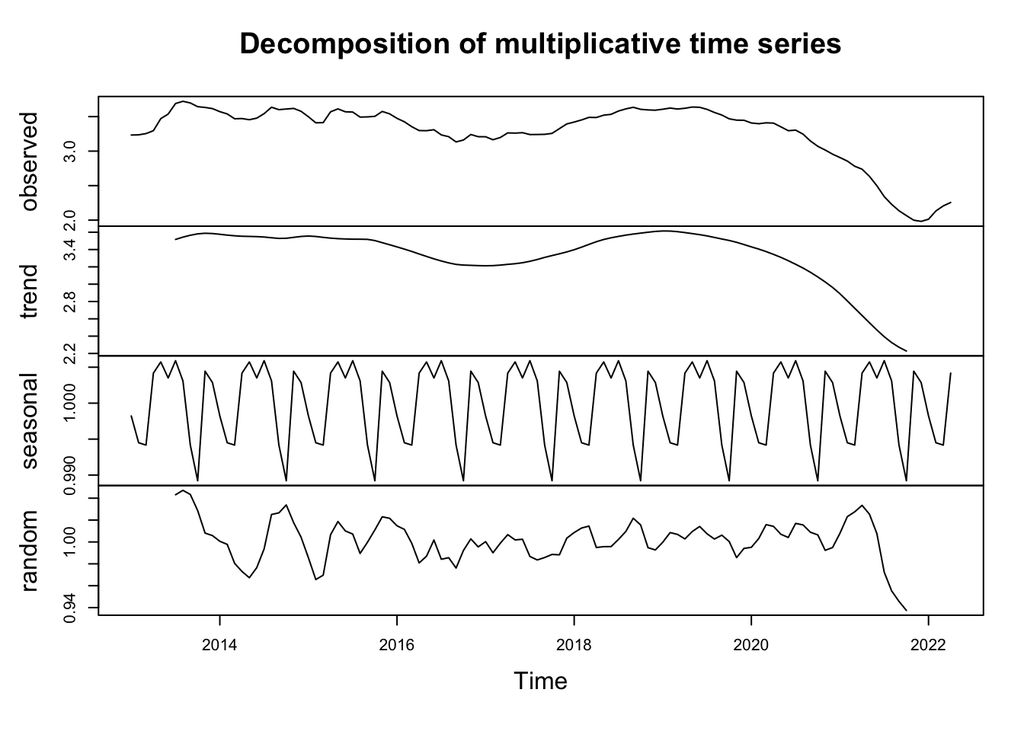

```r
gas <- read.csv("data/oil-gas.csv")[,-2]
gas_ts <- ts(gas$Gas, frequency = 12, c(2013,1), c(2022, 4))

tsn_gas_m <- decompose(gas_ts, type = "multiplicative")
plot(tsn_gas_m)
```

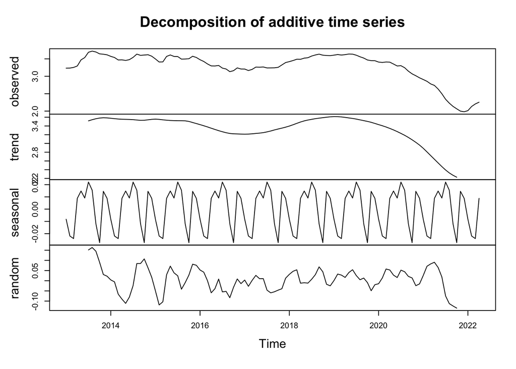

```r
tsn_gas_a <- decompose(gas_ts, type = "additive")
plot(tsn_gas_a)
```

## 4.2 Part B

Create forecasts for the gas data, with

1. naïve
2. seasonal naïve
3. simple exponential smooth
4. Holt
5. Holt-winters

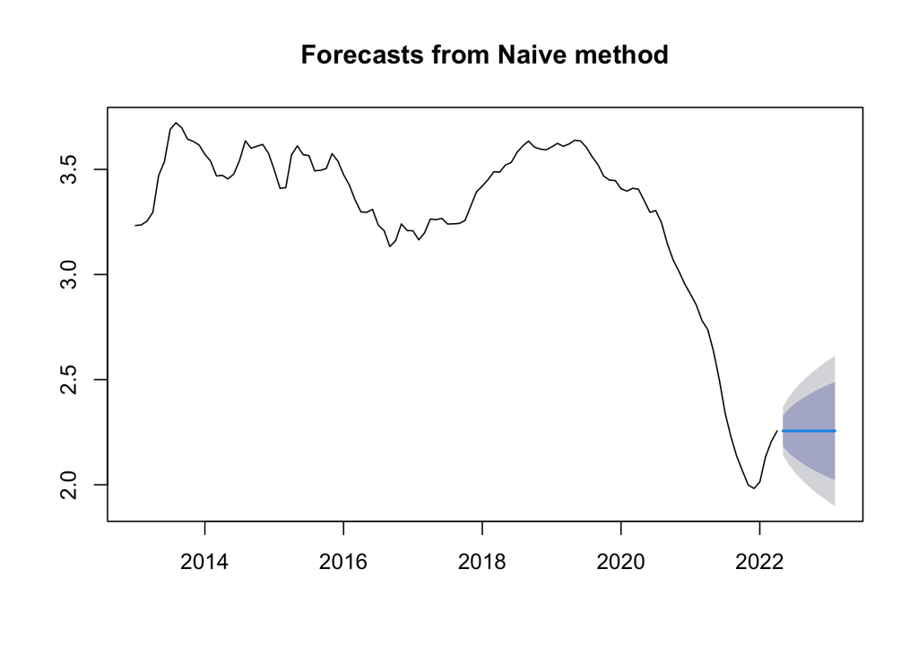

```r
gas_naive <- naive(gas_ts)
plot(gas_naive)
```

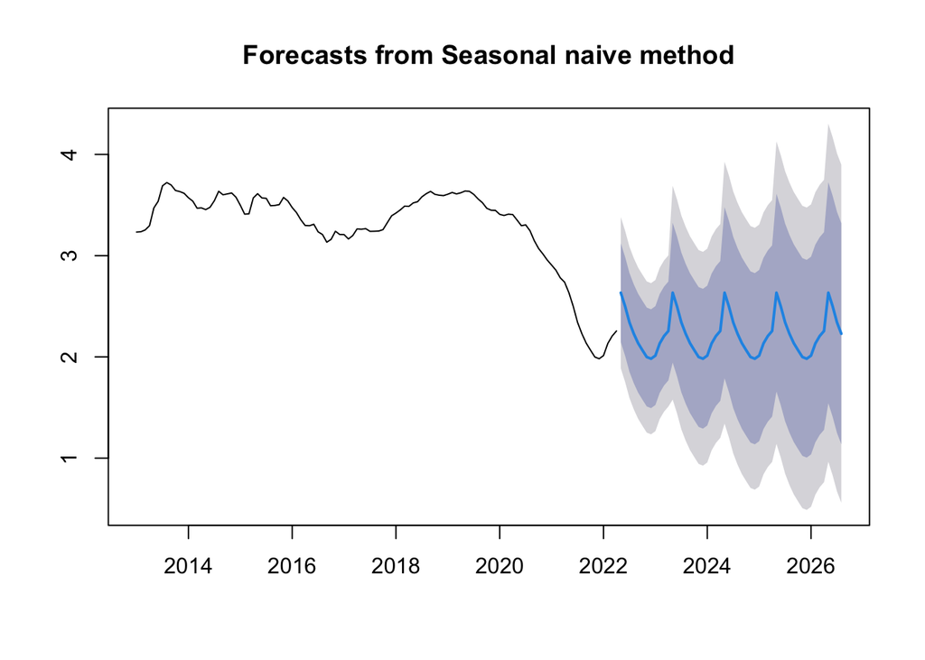

```r
gas_snaive <- snaive(gas_ts, h = 52)
plot(gas_snaive)
```

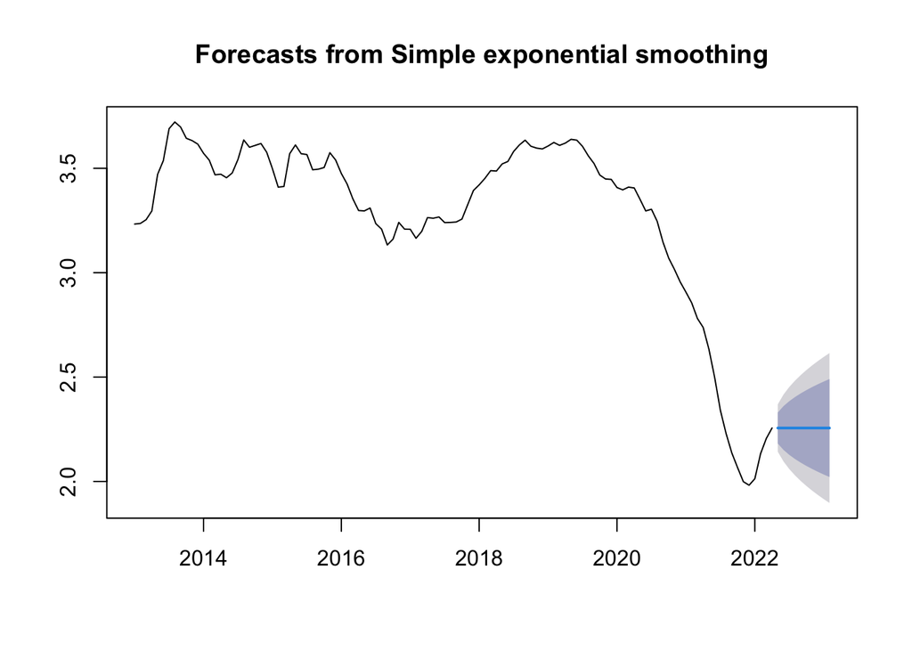

```r
gas_ses <- ses(gas_ts)
plot(gas_ses)
```

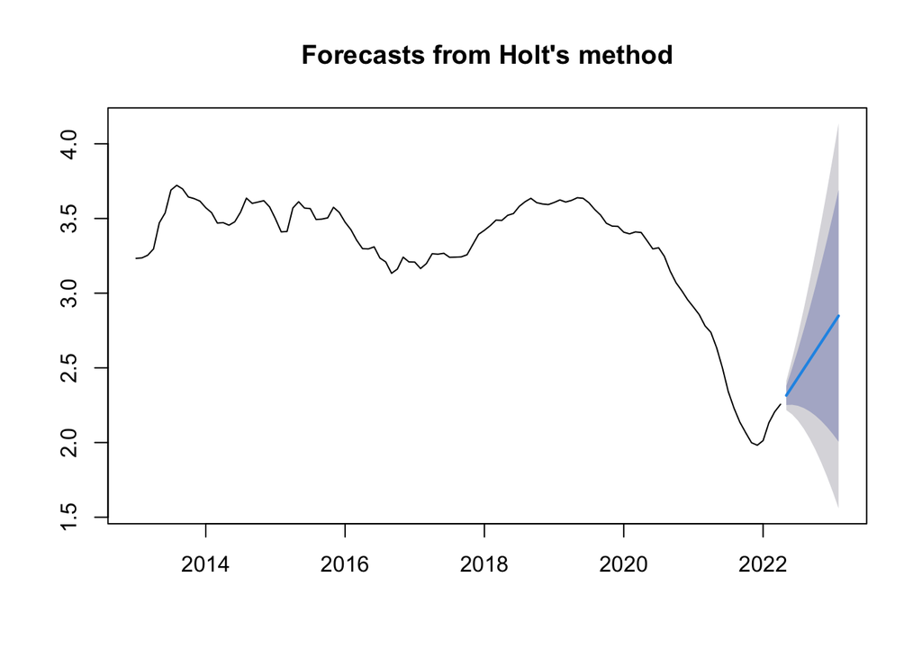

```r
gas_holt <- holt(gas_ts)
plot(gas_holt)
```

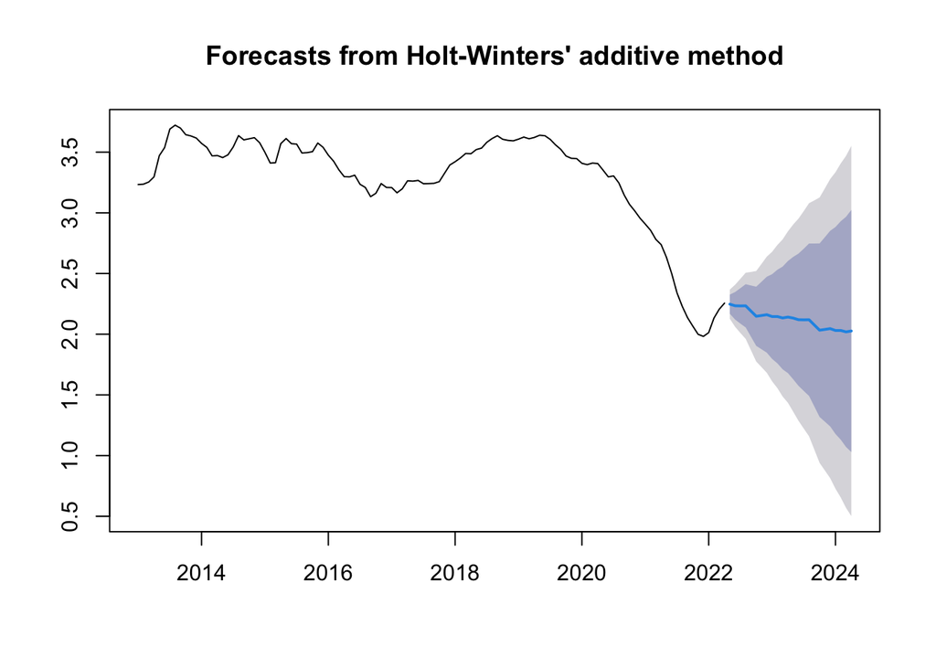

```r
gas_hw <- hw(gas_ts)
plot(gas_hw)
```

## 4.3 Part C

Calculate the MAPE’s for each of the models in (b). Which fits the best?

```r
mean(na.omit(abs(gas_naive$residuals)/gas_ts))
```

```
## [1] 0.01440786
```

```r
mean(na.omit(abs(gas_snaive$residuals)/gas_ts))
```

```
## [1] 0.1011711
```

```r
mean(abs(gas_ses$residuals)/gas_ts)
```

```
## [1] 0.01428026
```

```r
mean(abs(gas_holt$residuals)/gas_ts)
```

```
## [1] 0.01160892
```

```r
mean(abs(gas_hw$residuals)/gas_ts)
```

```
## [1] 0.01444441
```

Holt has the lowest MAPE.

## 4.4 Part D

Create a plot of the best forecast along with the fitted values to show the fit.

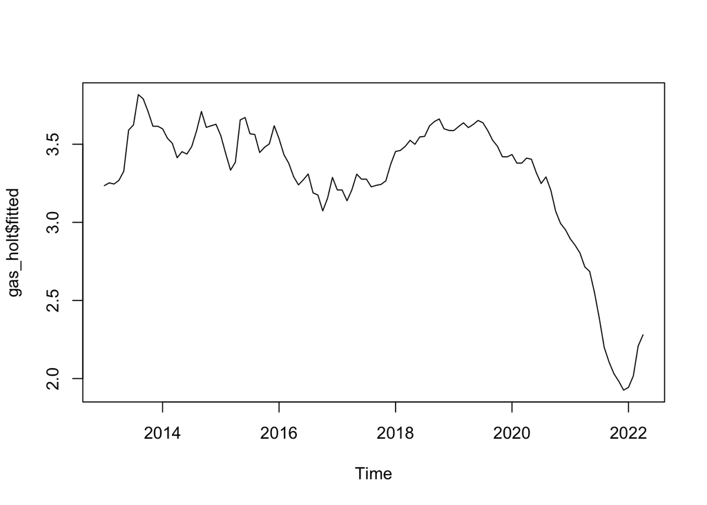

```r
plot(gas_holt$fitted)
```